# Lista 2 - Questão 3

Questão 1) Implemente uma função no R que recebe como argumentos x.train, y.train, x.test e k e que retorna como solução o estimador do KNN para cada elemento do conjunto de teste usando k vizinhos. Compare a velocidade de sua função com a função em um problema com $n.train=1000$ e $d=20$. Sugestão: para calcular distâncias, use a função .

Primeiramente iremos gerar os dados, serão gerados 1429 observações que serão divididas em 1000 (70%) para treinamento e 429 (30%) para teste, para isso utilizamos a geração de dados da lista 1.

```r
geradados=function(n,d){
  matrixdosdados= matrix(nrow=n,ncol=d)
  matrixdosdados[,1]=rep(1,n)
  for (i in 1:d) {
    matrixdosdados[,i]=rnorm(n,0,1)
  }
  return(matrixdosdados)
}
n=1429
X<-geradados(1429,20)
n<-1429
Betas.est<-c(2,-5,-3,5,7,8,3,2,-4,-5,8,-9,2,-5,-3,3,2,-4,-5,8) #betas dados
Betas<-as.matrix(Betas.est)
std.error<-rnorm(n,0,1) #erro
X<-as.matrix(X)
Y=X%*%Betas + std.error

dados<-data.frame(Y,X)

#DATA SPLITTING - HOLDOUT SIMPLES
linha <- sample(1:nrow(dados),nrow(dados)*0.7)
X.train <- dados[linha,]
X.teste <- dados[-linha,]

X_train <-X.train[,2:21]
X_teste <-X.teste[,2:21]
Y_train <-X.train[,1]
Y_teste <-X.teste[,1]
```

Cronstrução da função KNN

```r
KNN=function(x.train,y.train,x.test,K){
dist.one <-  function(x.new) {
  D=numeric(0)
  for (i in 1:nrow(x.train)){
    arg=as.numeric(x.new)-as.numeric(x.train[i,-ncol(x.train)])
    D[i] <- t(arg)%*%arg
  }
  return(D)
}
K=K
y.ch <- numeric(0)
for(i in 1:nrow(x.test)){
  Dist <- dist.one(x.test[i,-ncol(x.test)])
  dist.menores <- sort(Dist)[1:K]
  ind.n <- 1:nrow(x.train)
  ind<-ind.n[Dist<=dist.menores[K]]

  y.ch[i]=mean(y.train[ind])

}
return(y.ch)
}
pred=KNN(X_train,Y_train,X_teste,5)
system.time(KNN(X_train,Y_train,X_teste,5))
```

```
##    user  system elapsed
##   96.44    0.03   97.23
```

```r
mean((Y_teste-pred)^2)
```

```
## [1] 239.6461
```

Função knn no pacote FNN

```r
library(FNN)
ajuste <- knn.reg(train = X_train, test = X_teste,
                  y = Y_train, k = 5)

system.time(knn.reg(train = X_train, test = X_teste,y = Y_train, k = 5))
```

```
##    user  system elapsed
##    0.03    0.00    0.03
```

```r
predito <- ajuste$pred
sum((predito - Y_teste)^2)/429
```

```
## [1] 179.2674
```

Questão 2) Neste exercício você irá implementar algumas técnicas vistas em aula para o banco de dados das faces (). O objetivo aqui é conseguir criar uma função que consiga predizer para onde uma pessoa está olhando com base em uma foto. Iremos aplicar o KNN para esses dados, assim como uma regressão linear e florestas aleatórias. Como não é possível usar o método dos mínimos quadrados quando o número de covariáveis é maior que o número de observações, para esta segunda etapa iremos usar o lasso. Você pode usar funções prontas do R neste exercício.

1. Leia o banco . A primeira coluna deste banco contém a variável que indica a direção para a qual o indivíduo na imagem está olhando. As outras covariáveis contém os pixels relativos a essa imagem, que possui dimensão 64 por 64. Utilizando o comando , plote 5 imagens deste banco.

   ```
   Divida o conjunto fornecido em treinamento (aproximadamente 60\%  das observaçoes), validação
   (aproximadamente 20\%  das observaçoes)
   e teste (aproximadamente 20\% das observaçoes).
   Utilizaremos o conjunto de treinamento e validação para ajustar os modelos. O conjunto de teste será utilizado para testar sua performance.
   ```

```r
library(tm)
library(readr)
dados <- read_table2("C:/Users/ferna/Downloads/dadosFacesAltaResolucao.txt")
```

[figure not shown]

```r
m1=matrix(c(dados[1,2:4097]),64,64)
mode(m1) = "numeric"
image(m1)
```

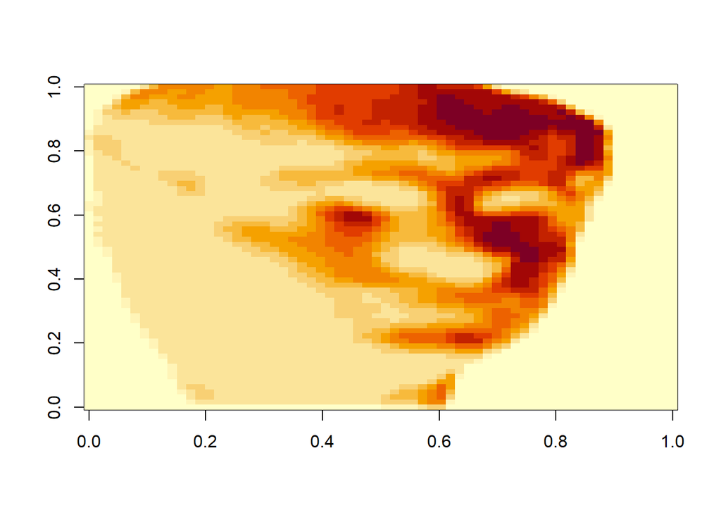

```r
m2=matrix(c(dados[2,2:4097]),64,64)
mode(m2) = "numeric"
image(m2)
```

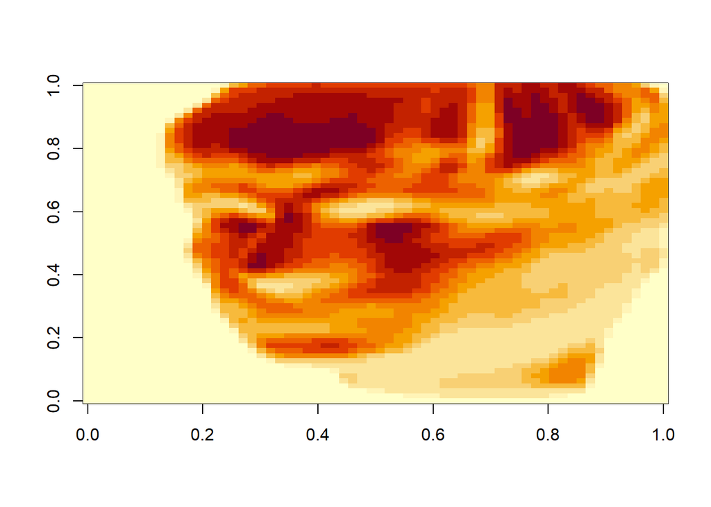

```r
m3=matrix(c(dados[3,2:4097]),64,64)
mode(m3) = "numeric"
image(m3)
```

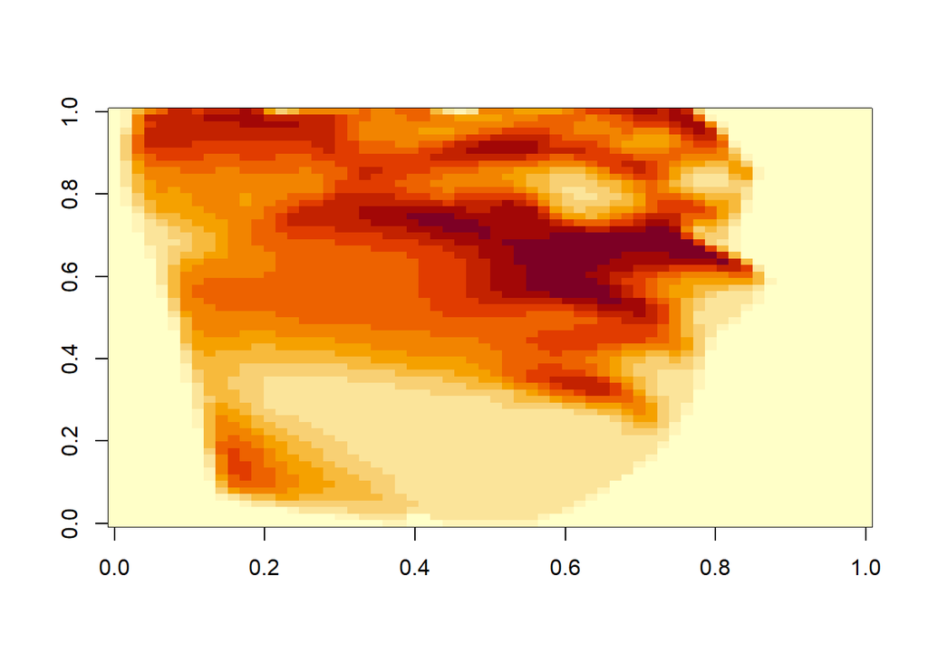

```r
m4=matrix(c(dados[4,2:4097]),64,64)
mode(m4) = "numeric"
image(m4)
```

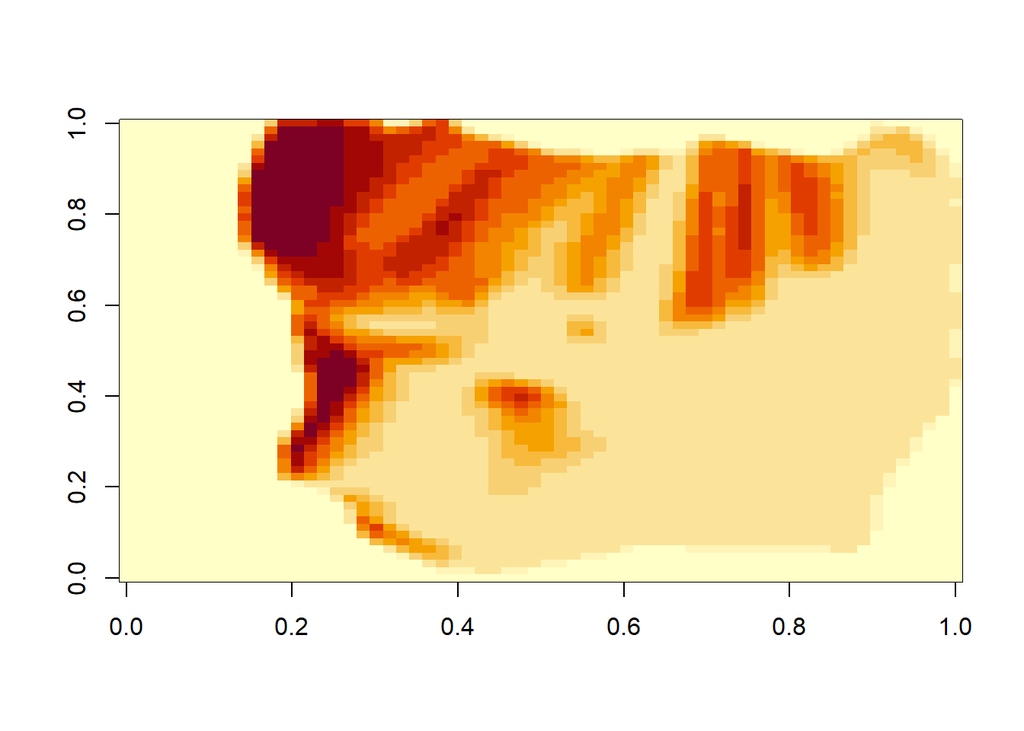

```r
m5=matrix(c(dados[5,2:4097]),64,64)
mode(m5) = "numeric"
image(m5)
```

```r
#pacote que será utilizado
require(MASS)
require(dplyr)
library(kimisc)

n=nrow(dados)

#truncando
n*70/100 # 488 para treinamento
```

```
## [1] 488.6
```

```r
n*30/100 # 210 para teste
```

```
## [1] 209.4
```

```r
#aleatorizando a base de dados

aleat<-sample_n(dados,nrow(dados))

Treino<- aleat[1:489,] # 70%

teste<-aleat[490:698,] # 30%

Teste<-teste[1:105,]

Valid<-teste[106:209,]
```

2. Qual o número de observações? Qual o número de covariáveis? O que representa cada covariável?

O número de observações é 698 O número de covariáveis é 4096 que representa os pixels da imagem “64x64” Tem uma representação númerica que indica a intesidade da cor no pixel correspondente.

3. Para cada observação $\x$ do conjunto de teste, calcule o estimador da função de regressão $r(\x)$ dado pelo método dos k vizinhos mais próximos com $k=5$. Você pode usar as funções vistas em aula.

```r
X_treino<-Treino[,2:4097]
Y_treino<-Treino[,1]
X_teste<-Teste[,2:4097]
Y_teste<-Teste[,1]
X_valid<-Valid[,2:4097]
Y_valid<-Valid[,1]
X_treino<-as.matrix(X_treino)
Y_treino<-as.matrix(Y_treino)
X_teste<-as.matrix(X_teste)
Y_teste<-as.matrix(Y_teste)
X_valid<-as.matrix(X_valid)
Y_valid<-as.matrix(Y_valid)

X_train_valid<-rbind(X_treino,X_valid)
Y_train_valid<-rbind(Y_treino,Y_valid)

k_grid <- round(seq(1, 100, length.out = 20))
error <- vector("numeric", length(k_grid))
for (i in seq_along(k_grid)) {
  fit <- FNN::knn.reg(train = X_train_valid,
                      y = Y_train_valid,
                      k = k_grid[i])
  error[i] <- mean((fit$pred - Y_train_valid)^2)
}
pred_knn <- FNN::knn.reg(train = X_train_valid,y = Y_train_valid,
                         test = X_teste,
                         k = 5)$pred
mean((pred_knn - Y_teste)^2)
```

```
## [1] 7.055599
```

```r
k_grid <- round(seq(1, 100, length.out = 30))
error <- vector("numeric", length(k_grid))
for (i in seq_along(k_grid)) {
  fit <- FNN::knn.reg(train = X_train_valid,
                      y = Y_train_valid,
                      k = k_grid[i])
  error[i] <- mean((fit$pred - Y_train_valid)^2)
}

pred_knn <- FNN::knn.reg(train = X_train_valid,y = Y_train_valid,
test = X_teste,k = k_grid[which.min(error)])$pred
mean((pred_knn - Y_teste)^2)
```

```
## [1] 7.222558
```

```r
risco=(pred_knn - Y_teste)^2
```

```r
library(glmnet)
treino<-Treino
valid<-Valid
test<-Teste
X_treino<-treino[,2:4097]
Y_treino<-treino[,1]
X_teste<-test[,2:4097]
Y_teste<-test[,1]
X_valid<-valid[,2:4097]
Y_valid<-valid[,1]
X_treino<-as.matrix(X_treino)
Y_treino<-as.matrix(Y_treino)
X_teste<-as.matrix(X_teste)
Y_teste<-as.matrix(Y_teste)
X_valid<-as.matrix(X_valid)
Y_valid<-as.matrix(Y_valid)

X_train_valid<-rbind(X_treino,X_valid)
Y_train_valid<-rbind(Y_treino,Y_valid)

cv_lasso=cv.glmnet(X_train_valid,Y_train_valid, alpha = 1)
cv_lasso
```

```
##
## Call:  cv.glmnet(x = X_train_valid, y = Y_train_valid, alpha = 1)
##
## Measure: Mean-Squared Error
##
##     Lambda Index Measure    SE Nonzero
## min 0.3236   100   33.04 4.324     111
## 1se 0.4481    93   36.85 4.779      95
```

```r
ajuste_lasso=glmnet(X_train_valid,Y_train_valid, alpha = 1)
ajuste_lasso
```

```
##
## Call:  glmnet(x = X_train_valid, y = Y_train_valid, alpha = 1)
##
##      Df  %Dev Lambda
## 1     0  0.00 32.360
## 2     2  5.15 30.890
## 3     2  9.89 29.480
## 4     4 14.84 28.140
## 5     5 19.96 26.860
## 6     6 24.68 25.640
## 7     5 28.98 24.480
## 8     7 32.94 23.360
## 9     7 36.61 22.300
## 10    7 40.02 21.290
## 11    9 43.22 20.320
```

[output cut: 89 more lines]

```r
predição_lasso=predict(ajuste_lasso, s = cv_lasso$lambda.1se, newx =  X_teste)
predição_lasso
```

```
##                 1
##   [1,]  50.488359
##   [2,]  17.964082
##   [3,]  59.364622
##   [4,]   7.114975
##   [5,] -41.028475
##   [6,] -21.622657
##   [7,]  22.946849
##   [8,] -20.925122
##   [9,]  16.233101
##  [10,] -71.443307
##  [11,]  14.412671
##  [12,] -52.768765
##  [13,] -33.587487
##  [14,] -22.580819
```

[output cut: 91 more lines]

```r
X_treino<-Treino[,2:4097]
Y_treino<-Treino[,1]
X_teste<-Teste[,2:4097]
Y_teste<-Teste[,1]
X_valid<-Valid[,2:4097]
Y_valid<-Valid[,1]
X_treino<-as.matrix(X_treino)
Y_treino<-as.matrix(Y_treino)
X_teste<-as.matrix(X_teste)
Y_teste<-as.matrix(Y_teste)
X_valid<-as.matrix(X_valid)
Y_valid<-as.matrix(Y_valid)
X_teste<-as.data.frame(X_teste)
X_train_valid<-rbind(X_treino,X_valid)
Y_train_valid<-rbind(Y_treino,Y_valid)
library(rpart)

fit <- rpart(Y_train_valid ~ X_train_valid,
             method = "anova")

melhor_cp <- fit$cptable[which.min(fit$cptable[, "xerror"]),
                         "CP"]

pfit <- rpart::prune(fit, cp = melhor_cp)

pred_arvore <- predict(pfit,newdata=X_teste)
nrow(X_teste)
```

```
## [1] 105
```

h)Ajuste uma rede neural com early-stopping. Estime o risco com o teste.

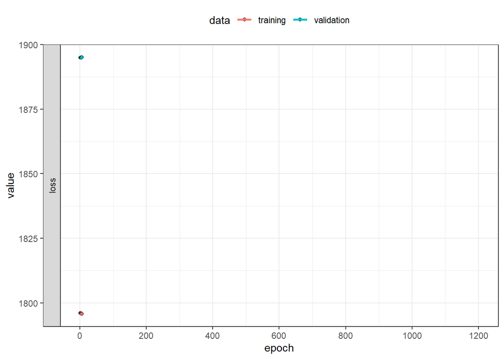

```r
library(rsample)
library(keras)
library(tensorflow)
X_treino<-Treino[,2:4097]
Y_treino<-Treino[,1]
X_teste<-Teste[,2:4097]
Y_teste<-Teste[,1]
X_valid<-Valid[,2:4097]
Y_valid<-Valid[,1]
X_treino<-as.matrix(X_treino)
Y_treino<-as.matrix(Y_treino)
X_teste<-as.matrix(X_teste)
Y_teste<-as.matrix(Y_teste)
X_valid<-as.matrix(X_valid)
Y_valid<-as.matrix(Y_valid)
X_train_valid<-rbind(X_treino,X_valid)
Y_train_valid<-rbind(Y_treino,Y_valid)

# especificação do modelo (uma rede feedforward com
# duas camadas ocultas com 8 neuronios cada)
modelo <- keras_model_sequential() %>%
  layer_dense(units = 8, activation = "relu",
              input_shape = ncol(X_train_valid)) %>%
  layer_dense(units = 8, activation = "relu") %>%
  layer_dense(units = 1)
# especificação da função objetivo e como ela será minimizada
modelo %>% compile(
  loss = "mse",
  optimizer = optimizer_rmsprop(),
  metrics = list("mean_absolute_error")
)
historico <- modelo %>% fit(X_train_valid,Y_train_valid,
epochs = 1200,validation_split = 0.17,callbacks=callback_early_stopping(monitor = "val_loss", patience = 5, mode = "min"),verbose = FALSE)
library(ggplot2)
  plot(historico, metrics = "loss") +
    theme_bw() + theme(legend.position = "top")
```

```r
  # valor predito no conjunto de teste
  predito <- modelo %>%
    predict(X_teste)

mean((predito - Y_teste)^2)
```

```
## [1] 1816.597
```